# import_template

Peekbank import template – hand-coded looking

This document lays out a template for importing a dataset that is hand-coded (or pre-processed into area of interest codes) to the Peekbank format. You’ll start with your data files and end up with a set of .csv files that correspond to tables in the Peekbank database.

First, we set some constants and file paths. Your data will need to be in the folder “data/your_dataset_name/raw_data” starting from your working directory.

```r
sampling_rate_hz <- 30
sampling_rate_ms <- 1000/30
dataset_name <- "adams_marchman_2018" # change to your_dataset_name
read_path <- here("data", dataset_name,"raw_data")
write_path <- here("data", dataset_name, "processed_data")
```

Let’s read in the data. Here we’re using a helper function (read_data) written to load in this dataset correctly; you’ll likely have to write a bit of custom code to read in your data. Ultimately, you want one table with one row per time point, and columns for at least: subject ID, subject age in months, subject sex, trial order, target and distractor labels, target side, coded looking (area of interest), and time in milliseconds.

After loading in this dataset, it’s nearly there, but it’s in wide format: there is one row per trial, and time points are coded separately in columns. Let’s look at a few rows of some select columns. The numerically named columns are separate time points (e.g., t = 100 ms) within a trial.

```r
raw_data <- read_data(read_path)

raw_data %>%
  select(sub_num, months, sex, trial_order, r_image, l_image,
                            target_side, `-600`, `0`, `100`, `300`) %>%
  slice(1:5) %>%
  kable() %>% kable_styling()
```

| sub_num | months | sex | trial_order | r_image | l_image | target_side | -600 | 0 | 100 | 300 |
| --- | --- | --- | --- | --- | --- | --- | --- | --- | --- | --- |
| 11003 | 17 | F | 1 | baby1 | doggy1 | r | 1 | 0 | 0 | 0 |
| 11003 | 17 | F | 2 | book1 | car1 | l | 0 | 1 | 1 | 1 |
| 11003 | 17 | F | 3 | ball1 | shoe1 | r | 1 | 0 | 0 | 0 |
| 11003 | 17 | F | 4 | baby2 | doggy2 | l | 1 | 1 | 1 | 1 |
| 11003 | 17 | F | 5 | ball2 | shoe2 | l | 0 | 1 | 1 | 1 |

Let’s pivot_longer so we have one row per time point. Coded looking (area of interest, or AOI) is coded numerically, so let’s also convert that to the correct format (target, distractor, other, missing).

```r
d_tidy <- raw_data %>%
    pivot_longer(names_to = "t", cols = `-600`:`3833`, values_to = "aoi")

d_tidy <- d_tidy %>%
  rename(aoi_old = aoi) %>%
  mutate(aoi = case_when(
    aoi_old == "0" ~ "distractor",
    aoi_old == "1" ~ "target",
    aoi_old == "0.5" ~ "other",
    aoi_old == "." ~ "missing",
    aoi_old == "-" ~ "missing",
    is.na(aoi_old) ~ "missing"
  )) %>%
  mutate(t = as.numeric(t))

d_tidy %>%
  select(t, sub_num, months, sex, trial_order, r_image, l_image,
                            target_side, aoi) %>%
  slice(1:5) %>%
  kable() %>% kable_styling()
```

| t | sub_num | months | sex | trial_order | r_image | l_image | target_side | aoi |
| --- | --- | --- | --- | --- | --- | --- | --- | --- |
| -600 | 11003 | 17 | F | 1 | baby1 | doggy1 | r | target |
| -567 | 11003 | 17 | F | 1 | baby1 | doggy1 | r | target |
| -533 | 11003 | 17 | F | 1 | baby1 | doggy1 | r | target |
| -500 | 11003 | 17 | F | 1 | baby1 | doggy1 | r | target |
| -467 | 11003 | 17 | F | 1 | baby1 | doggy1 | r | target |

Next, let’s get rid of some columns we don’t need and rename others to fix the schema. In this dataset, the target and distractor sides (left, right) are coded from the coder’s perspective–let’s switch that to the participant’s perspective. We’ll make a column for the target_label, the label used for the target object (like “baby”, “kitty” or “shoe”).

```r
d_tidy <- d_tidy %>%
  filter(!is.na(sub_num)) %>%
  select(-prescreen_notes, -c_image,-response,-condition, -first_shift_gap,-rt) %>%
  # flip left-right to participant's perspective
  mutate(target_side = factor(target_side, levels = c('l','r'), labels = c('right','left'))) %>%
  rename(left_image = r_image, right_image = l_image) %>%
  # target label is already given in the target_image column
  mutate(target_label = target_image) %>%
  rename(target_image_old = target_image) %>%
  # now rename target_image using the left_image and right_image columns
  mutate(target_image = case_when(target_side == "right" ~ right_image,
                                      TRUE ~ left_image)) %>%
  mutate(distractor_image = case_when(target_side == "right" ~ left_image,
                                      TRUE ~ right_image)) %>%
  filter(!(sub_num == "12608" & sex == "M"))
  # one participant has different entries for sex - 12608 is female via V Marchman
  # just filter out this participant

d_tidy %>%
  select(t, sub_num, months, sex, trial_order, target_label, target_image, distractor_image,
                            target_side, aoi) %>%
  slice(1:5) %>%
  kable() %>% kable_styling()
```

| t | sub_num | months | sex | trial_order | target_label | target_image | distractor_image | target_side | aoi |
| --- | --- | --- | --- | --- | --- | --- | --- | --- | --- |
| -600 | 11003 | 17 | F | 1 | baby | baby1 | doggy1 | left | target |
| -567 | 11003 | 17 | F | 1 | baby | baby1 | doggy1 | left | target |
| -533 | 11003 | 17 | F | 1 | baby | baby1 | doggy1 | left | target |
| -500 | 11003 | 17 | F | 1 | baby | baby1 | doggy1 | left | target |
| -467 | 11003 | 17 | F | 1 | baby | baby1 | doggy1 | left | target |

Now we have nearly all the data we need, all in one big table. We want to split this up into multiple tables–a subjects table, stimulus table, trials table, AOI timepoints table (with coded looking at each time point), and so on–all linked with unique IDs so they can be stored efficiently and joined back together selectively.

Let’s start with the stimulus table by grabbing all distinct target images and labels. In this dataset, all distractor images are also used as target images, so pulling target images is sufficient to get all image-label pairings. Here, all stimuli are familiar and all the labels in the dataset are English stimulus labels, so these can just be copied over from the target_label column. Finally, we make a stimulus ID that uniquely identifies image-label pairings, indexed from zero.

```r
stimulus_table <- d_tidy %>%
  distinct(target_image, target_label) %>%
  filter(!is.na(target_image)) %>%
  mutate(dataset_id = 0,
         stimulus_novelty = "familiar",
         original_stimulus_label = target_label,
         english_stimulus_label = target_label,
         stimulus_image_path = target_image,
         lab_stimulus_id = target_image
  ) %>%
  mutate(stimulus_id = seq(0, length(.$lab_stimulus_id) - 1))
```

Next, we’ll join that stimulus table back into our big dataset table, by the target label and then by the distractor label, so we have target IDs and distractor IDs for each trial that link up to the stimulus table.

```r
d_tidy <- d_tidy %>%
  left_join(stimulus_table %>% select(lab_stimulus_id, stimulus_id),
            by=c('target_image' = 'lab_stimulus_id')) %>%
  mutate(target_id = stimulus_id) %>%
  select(-stimulus_id) %>%
  left_join(stimulus_table %>% select(lab_stimulus_id, stimulus_id),
            by=c('distractor_image' = 'lab_stimulus_id')) %>%
  mutate(distractor_id = stimulus_id) %>%
  select(-stimulus_id)

d_tidy %>%
  select(t, sub_num, months, sex, trial_order, target_id, distractor_id,
                            target_side, aoi) %>%
  slice(1:5) %>%
  kable() %>% kable_styling()
```

| t | sub_num | months | sex | trial_order | target_id | distractor_id | target_side | aoi |
| --- | --- | --- | --- | --- | --- | --- | --- | --- |
| -600 | 11003 | 17 | F | 1 | 0 | 22 | left | target |
| -567 | 11003 | 17 | F | 1 | 0 | 22 | left | target |
| -533 | 11003 | 17 | F | 1 | 0 | 22 | left | target |
| -500 | 11003 | 17 | F | 1 | 0 | 22 | left | target |
| -467 | 11003 | 17 | F | 1 | 0 | 22 | left | target |

Now we’ll do the same thing for subjects: get all the distinct subjects in the big table, give them unique subject IDs, and then join those back in to the big table.

We’ll then use those subject IDs to create administration IDs–unique IDs for each administration of the experiment, linked to the subject’s age at the time and some experiment parameters like the eyetracker or coding method. Note that if your dataset is longitudinal, you’ll have multiple administration IDs per subject, but otherwise you will likely have one administration per subject.

```r
d_subject_ids <- d_tidy %>%
  distinct(sub_num) %>%
  mutate(subject_id = seq(0, length(.$sub_num) - 1))

# join back in subject IDs
d_tidy <- d_tidy %>%
  left_join(d_subject_ids, by = "sub_num")

# create administration IDs
d_administration_ids <- d_tidy %>%
  distinct(subject_id, sub_num, months, order_uniquified) %>%
  arrange(subject_id, sub_num, months, order_uniquified) %>%
  mutate(administration_id = seq(0, length(.$order_uniquified) - 1))
```

Next, let’s make a table of trial types. These are unique pairings of targets, distractors, target side (left or right) and full phrases (e.g., “Do you see the ball?”) used to prompt looking to the target. We also need to specify the condition manipulation in that trial.

In this dataset, there are no meaningful trial conditions, so we can leave that as an empty string. We don’t know the full phrase, so we will leave that as `NA`. Just as with subjects, we’ll create unique zero-indexed trial type IDs and join them back in to the big table.

Finally, using these trial IDs, we’ll create a trials table. This table is distinct from the trial types table and specifies the different trial orderings subjects can see. If your experiment has only one trial ordering, this table will have a row for each `trial_order` (0, 1, 2, …) in the experiment, each associated with a `trial_type_id` linked to the `trial_types` table. If there are multiple trial orderings in your experiment, this table will encode each correspondence between trial types and positions in the trial order that was seen by a subject.

```r
d_trial_type_ids <- d_tidy %>%
  distinct(trial_order, target_id, distractor_id, target_side) %>%
  mutate(full_phrase = NA, # unknown
         condition = "") %>% # no trial-wise condition manipulation
  mutate(trial_type_id = seq(0, length(trial_order) - 1))

# join in trial type IDs and administration IDs
d_tidy <- d_tidy %>%
  left_join(d_administration_ids) %>%
  left_join(d_trial_type_ids)

# get trial IDs for the trials table
d_trial_ids <- d_tidy %>%
  distinct(trial_order, trial_type_id) %>%
  mutate(trial_id = seq(0, length(.$trial_type_id) - 1))

# join in trial IDs
d_tidy <- d_tidy %>%
  left_join(d_trial_ids)
```

Now our big table has all the IDs we need. Let’s add a few columns and do some renaming in this table to make it consistent with the schema. We’ll make the final tables that will be saved as .csv files and uploaded to Peekbank by making distinct selections from this big table.

```r
d_tidy <- d_tidy %>%
  mutate(dataset_id = 0, # dataset id is always zero since there's only one dataset
         lab_trial_id = paste(order, tr_num, sep = "-"),
         aoi_region_set_id = NA, # not applicable
         monitor_size_x = NA, # unknown
         monitor_size_y = NA, # unknown
         lab_age_units = "months",
         age = as.numeric(months),
         point_of_disambiguation = 0, # data was already centered at point_of_disambiguation
         tracker = "video_camera",
         sample_rate = sampling_rate_hz) %>%
  rename(lab_subject_id = sub_num,
         lab_age = months)
```

From the big table, let’s make the `aoi_timepoints` table. If time in your dataset doesn’t restart on each trial, you’ll need to call `rezero_times()`; once it is zeroed at the beginning of each trial, you’ll need to call `normalize_times()` to center it at the `point_of_disambiguation`.

Since this dataset already has timepoints centered at the `point_of_disambiguation`, there’s no need to rezero or normalize them. We’ll call the `resample_times` function on this table to resample timepoints at a consistent rate. Let’s look at that finished `aoi_timepoints` table.

```r
aoi_table <- d_tidy %>%
  rename(t_norm = t) %>% # original data centered at point of disambiguation
  select(t_norm, aoi, trial_id, administration_id, lab_subject_id) %>%
  #resample timepoints
  resample_times(table_type = "aoi_timepoints") %>%
  mutate(aoi_timepoint_id = seq(0, nrow(.) - 1)) # create zero-indexed IDs for aoi_timepoints table

aoi_table %>%
  slice(1:5) %>%
  kable() %>% kable_styling()
```

| t_norm | aoi | trial_id | administration_id | aoi_timepoint_id |
| --- | --- | --- | --- | --- |
| -600 | target | 0 | 0 | 0 |
| -575 | target | 0 | 0 | 1 |
| -550 | target | 0 | 0 | 2 |
| -525 | target | 0 | 0 | 3 |
| -500 | target | 0 | 0 | 4 |

Let’s create the final subjects table by getting all distinct subjects from the big table and recoding sex to fit the schema. All the `subjects` here have English as a native language, so we’ll code that as well. We’ll do the same for the `administrations` table. Let’s look at a selection from each of these final tables.

```r
subjects <- d_tidy %>%
  distinct(subject_id, lab_subject_id, sex) %>%
  mutate(sex = factor(sex, levels = c('M','F'), labels = c('male','female')),
         native_language = "eng")

subjects %>% slice(1:5) %>%
  kable() %>% kable_styling()
```

| lab_subject_id | sex | subject_id | native_language |
| --- | --- | --- | --- |
| 11003 | female | 0 | eng |
| 11009 | female | 1 | eng |
| 11011 | male | 2 | eng |
| 11014 | male | 3 | eng |
| 11035 | male | 4 | eng |

```r
administrations <- d_tidy %>%
  distinct(administration_id,
           dataset_id,
           subject_id,
           age,
           lab_age,
           lab_age_units,
           monitor_size_x,
           monitor_size_y,
           sample_rate,
           tracker) %>%
  mutate(coding_method = "manual gaze coding") # add coding type

administrations %>% slice(1:5) %>%
  select(lab_age, subject_id, administration_id, lab_age_units, age, sample_rate, coding_method) %>%
  kable() %>% kable_styling()
```

| lab_age | subject_id | administration_id | lab_age_units | age | sample_rate | coding_method |
| --- | --- | --- | --- | --- | --- | --- |
| 17 | 0 | 0 | months | 17 | 30 | manual gaze coding |
| 17 | 0 | 1 | months | 17 | 30 | manual gaze coding |
| 19 | 0 | 2 | months | 19 | 30 | manual gaze coding |
| 19 | 0 | 3 | months | 19 | 30 | manual gaze coding |
| 16 | 1 | 4 | months | 16 | 30 | manual gaze coding |

We’ll do the same with the `stimuli` table, the `trials` table, and the `trial_types` table.

```r
stimulus_table <- stimulus_table %>%
  # we already made a stimulus table that roughly fits the schema,
  # so we'll pull from that instead of from the big table
  select(-target_label, -target_image)

stimulus_table %>% slice(1:5) %>%
  kable() %>% kable_styling()
```

| dataset_id | stimulus_novelty | original_stimulus_label | english_stimulus_label | stimulus_image_path | lab_stimulus_id | stimulus_id |
| --- | --- | --- | --- | --- | --- | --- |
| 0 | familiar | baby | baby | baby1 | baby1 | 0 |
| 0 | familiar | car | car | car1 | car1 | 1 |
| 0 | familiar | ball | ball | ball1 | ball1 | 2 |
| 0 | familiar | doggy | doggy | doggy2 | doggy2 | 3 |
| 0 | familiar | shoe | shoe | shoe2 | shoe2 | 4 |

```r
trials_table <- d_tidy %>%
  distinct(trial_id,
           trial_order,
           trial_type_id)

trials_table %>% slice(1:5) %>%
  kable() %>% kable_styling()
```

| trial_order | trial_type_id | trial_id |
| --- | --- | --- |
| 1 | 0 | 0 |
| 2 | 1 | 1 |
| 3 | 2 | 2 |
| 4 | 3 | 3 |
| 5 | 4 | 4 |

```r
trial_types_table <- d_tidy %>%
  distinct(trial_type_id,
           full_phrase,
           point_of_disambiguation,
           target_side,
           lab_trial_id,
           aoi_region_set_id,
           dataset_id,
           target_id,
           distractor_id) %>%
    mutate(full_phrase_language = "eng")

trial_types_table %>% slice(1:5) %>%
  select(trial_type_id, target_id, distractor_id, target_side, point_of_disambiguation,
         full_phrase, full_phrase_language) %>%
  kable() %>% kable_styling()
```

| trial_type_id | target_id | distractor_id | target_side | point_of_disambiguation | full_phrase | full_phrase_language |
| --- | --- | --- | --- | --- | --- | --- |
| 0 | 0 | 22 | left | 0 | NA | eng |
| 1 | 1 | 23 | right | 0 | NA | eng |
| 2 | 2 | 24 | left | 0 | NA | eng |
| 3 | 3 | 25 | right | 0 | NA | eng |
| 4 | 4 | 17 | right | 0 | NA | eng |

Finally, let’s add the `datasets` table, with all the datasets we’re importing. We’re only importing one dataset here. We’ll add the dataset name here to identify this dataset, as well as the citation for the relevant paper the data are used in and a shortened citation.

```r
datasets <- tibble(
  dataset_id = 0, # make 0 for all
  dataset_name = dataset_name,
  lab_dataset_id = dataset_name, # internal name from the lab (if known)
  cite = "Adams, K. A., Marchman, V. A., Loi, E. C., Ashland, M. D., Fernald, A., & Feldman, H. M. (2018). Caregiver talk and medical risk as predictors of language outcomes in full term and preterm toddlers. Child Development, 89(5), 1674–1690. https://doi.org/10.1111/cdev.12818",
  shortcite = "Adams et al. (2018)"
  )

datasets %>% slice(1:5) %>%
  kable() %>% kable_styling()
```

| dataset_id | dataset_name | lab_dataset_id | cite | shortcite |
| --- | --- | --- | --- | --- |
| 0 | adams_marchman_2018 | adams_marchman_2018 | Adams, K. A., Marchman, V. A., Loi, E. C., Ashland, M. D., Fernald, A., & Feldman, H. M. (2018). Caregiver talk and medical risk as predictors of language outcomes in full term and preterm toddlers. C… | Adams et al. (2018) |

That’s it! Now we write all the files and validate that they fit the schema. These are commented out so you don’t accidentally write a bunch of files when running this script.

```r
#write_csv(aoi_table, fs::path(write_path, aoi_table_filename))
#write_csv(subjects, fs::path(write_path, subject_table_filename))
#write_csv(administrations, fs::path(write_path, administrations_table_filename))
#write_csv(stimulus_table, fs::path(write_path, stimuli_table_filename))
#write_csv(trials_table, fs::path(write_path, trials_table_filename))
#write_csv(trial_types_table, fs::path(write_path, trial_types_table_filename))
#write_csv(datasets, fs::path(write_path, dataset_table_filename))

# validation check
# validate_for_db_import(dir_csv = write_path)
```

Finally, once the data passes a validation check, it’s useful to plot the data to see if it passes the “eyecheck” of what looking-while-listening data typically looks like (and e.g. to compare it to existing plots if the dataset is from a published paper). Here’s an example of this visual “validation check”

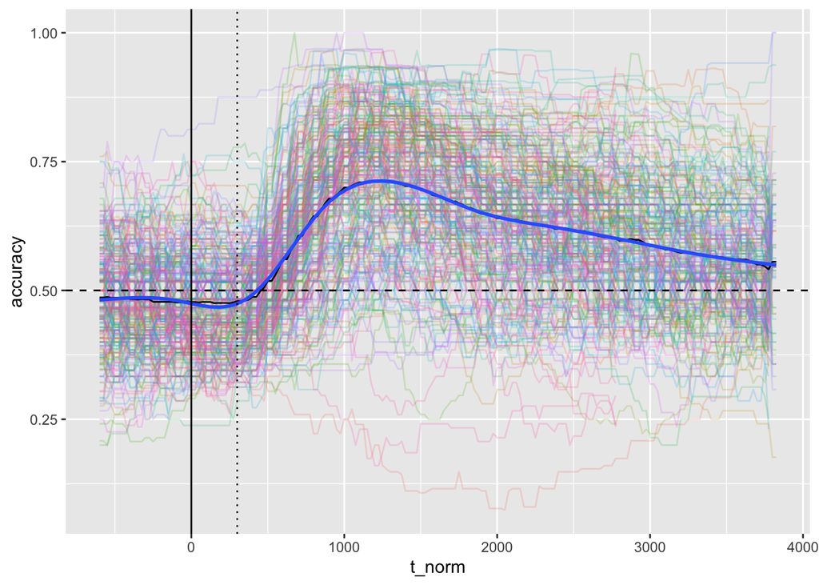

```r
#### Plot Timecourse ####

#rename columns for distractor
distractor_stimulus_table <- stimulus_table
colnames(distractor_stimulus_table) <- paste("distractor_",colnames(stimulus_table),sep="")

#join to full dataset
full_data <- aoi_table %>%
  left_join(administrations) %>%
  left_join(trials_table) %>%
  left_join(trial_types_table) %>%
  left_join(stimulus_table,by=c("target_id"="stimulus_id","dataset_id")) %>%
  left_join(distractor_stimulus_table %>% select(-distractor_dataset_id),by=c("distractor_id"="distractor_stimulus_id"))
#mutate aoi
full_data <- full_data %>%
  mutate(aoi_new=case_when(
    aoi=="target" ~ 1,
    aoi=="distractor"~0,
    aoi=="missing"~ NaN
  )) %>%
  mutate(aoi_new=ifelse(is.nan(aoi_new),NA,aoi_new))

##### summarize by subject (really: administrations) ####
summarize_by_subj <- full_data %>%
  group_by(administration_id, t_norm) %>%
  summarize(N=sum(!is.na(aoi_new)),mean_accuracy=mean(aoi_new,na.rm=TRUE))
#### summarize across subjects ####
summarize_across_subj <- summarize_by_subj %>%
  group_by(t_norm) %>%
  summarize(N=sum(!is.na(mean_accuracy)),
         accuracy=mean(mean_accuracy,na.rm=TRUE),
         sd_accuracy=sd(mean_accuracy,na.rm=TRUE))

#plot (remove data points where not a lot of subjects contributed, to avoid discontinuities in the slope)
ggplot(filter(summarize_across_subj,N>length(unique(full_data$administration_id))/3),aes(t_norm,accuracy))+
  geom_line(data=filter(summarize_by_subj,N>10),aes(y=mean_accuracy,color=as.factor(administration_id),group=as.factor(administration_id)),alpha=0.2)+
  geom_line()+
  geom_smooth(method="gam",se=FALSE)+
  geom_vline(xintercept=0)+
  geom_vline(xintercept=300,linetype="dotted")+
  geom_hline(yintercept=0.5,linetype="dashed")+
  theme(legend.position="none")
```

Once all validation checks are passed, data should be uploaded to the Open Science Framework project page (https://osf.io/pr6wu/).